# EGRMGMT 590.21 Homework 6 (Questions)

## Instructions

- Use R Markdown to complete the exercises in order. Please show both your R code and its corresponding output
- There are 10 exercises in total, each of which is worth 10 points
- One exercise can be potentially solved in multiple ways. The grade is based on the output accuracy, not on performance
- Submit the completed homework in a .html file to Sakai by **6:15pm ET on Thursday, October 24**. Assignments handed in late will lose 10 points each day after the due date
- For more information about R Markdown, please visit the two links in the References/Readings slide in the week 2 deck

## Exercises

### Exercise 1 (10 Points)

- Read the monthly sales data from “retail.xlsx” and use the ts() function to create a time series object named sales.ts with the monthly sales values and their corresponding periods
- Plot sales.ts with the horizontal axis indicating time and the vertical axis indicating monthly sales

```r
library(forecast)
```

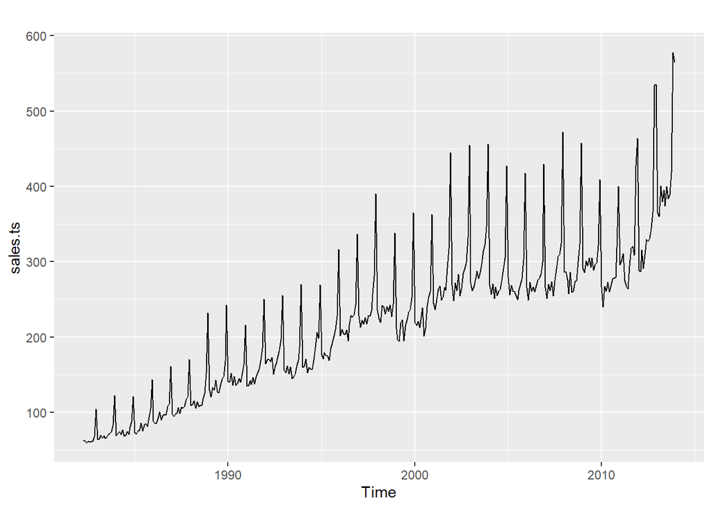

```r
library(readxl)
sales <- read_excel("retail.xlsx")
sales.ts <- ts(sales[,2], start = c(1982, 4), frequency = 12)
autoplot(sales.ts)
```

### Exercise 2 (10 Points)

- Apply the ma() function of the forecast library to create the 12-month moving average of sales.ts
- Plot the original time series sales.ts and its moving average on the same line chart

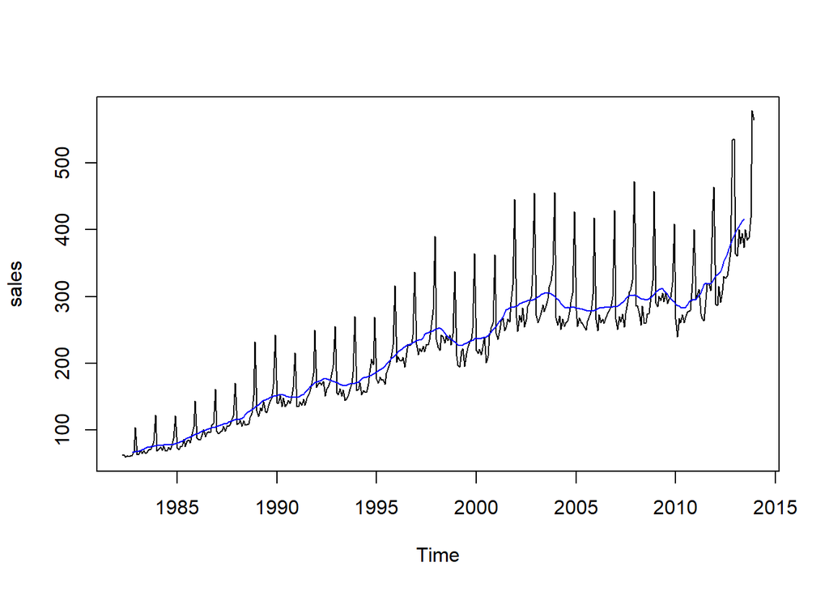

```r
plot(sales.ts)
sales.maverage <- ma(sales.ts,order=12)
lines(sales.maverage,col ="blue")
```

### Exercise 3 (10 Points)

- Apply the decompose() function to decompose sales.ts into the trend, seasonal, and random components using the multiplicative decomposition method
- Plot the resulting trend, seasonal, and random components accordingly

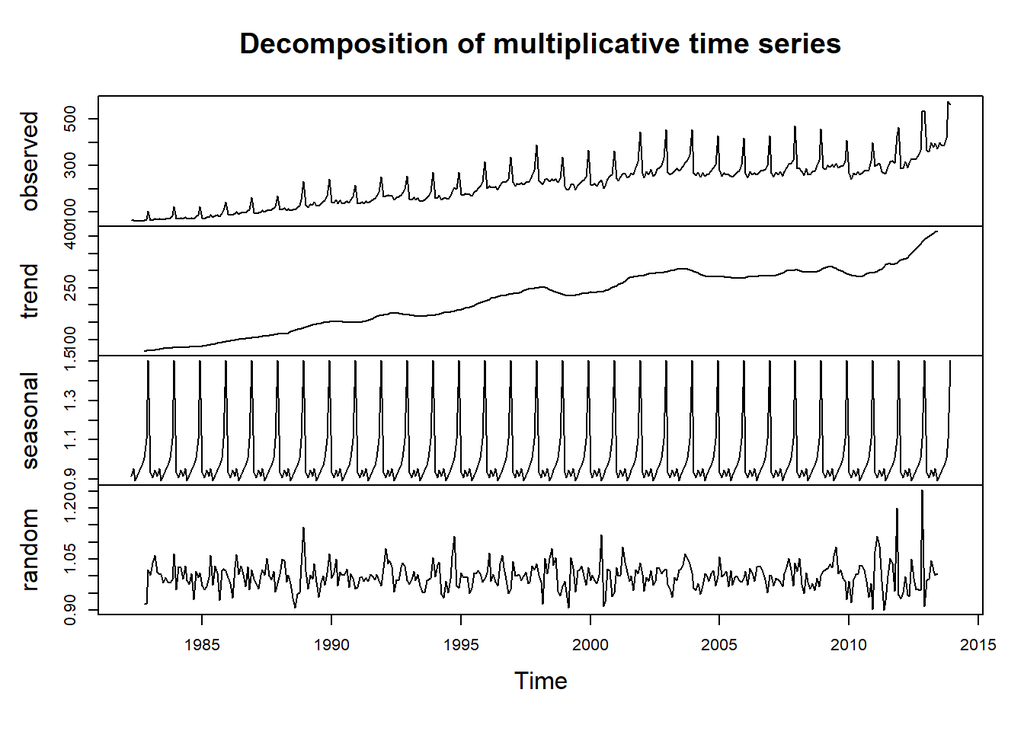

```r
que3 <- decompose(sales.ts, type =  "multiplicative", filter = NULL)
plot(que3)
```